# EDA

Agata Kaczmarek & Agata Makarewicz & Jacek Wiśniewski

27 03 2021

### Dataset

At the beginning, we would like to see how our data looks like eg. what are column names, values and the structure of whole data set.

| name | brand | back_camera_mpix | front_camera_mpix | battery_mAh | ram_gb | flash_gb | diag | height_px | width_px | price |
| --- | --- | --- | --- | --- | --- | --- | --- | --- | --- | --- |
| Xiaomi Mi 10T 6+128GB | Xiaomi | 64 | 20 | 5000 | 6 | 128 | 6.67 | 2400 | 1080 | 1999 |
| Samsung Galaxy M21 | Samsung | 48 | 20 | 6000 | 4 | 64 | 6.40 | 2340 | 1080 | 899 |
| Samsung Galaxy Note20 | Samsung | 64 | 10 | 4300 | 8 | 256 | 6.70 | 2400 | 1080 | 3749 |
| Xiaomi Redmi 9 4+64 | Xiaomi | 13 | 8 | 5020 | 4 | 64 | 6.53 | 2340 | 1080 | 619 |
| Xiaomi Redmi Note 8 Pro 6/64GB | Xiaomi | 64 | 20 | 4500 | 6 | 64 | 6.53 | 2340 | 1080 | 769 |
| Samsung Galaxy M31s | Samsung | 64 | 32 | 6000 | 6 | 128 | 6.50 | 2340 | 1080 | 1399 |

##### Structure

```
## 'data.frame':    414 obs. of  11 variables:
##  $ name             : chr  "Xiaomi Mi 10T 6+128GB " "Samsung Galaxy M21 " "Samsung Galaxy Note20 " "Xiaomi Redmi 9 4+64 " ...
##  $ brand            : chr  "Xiaomi" "Samsung" "Samsung" "Xiaomi" ...
##  $ back_camera_mpix : num  64 48 64 13 64 64 48 48 48 13 ...
##  $ front_camera_mpix: int  20 20 10 8 20 32 13 13 8 5 ...
##  $ battery_mAh      : int  5000 6000 4300 5020 4500 6000 5000 5020 5000 5000 ...
##  $ ram_gb           : num  6 4 8 4 6 6 3 4 4 2 ...
##  $ flash_gb         : int  128 64 256 64 64 128 32 128 64 32 ...
##  $ diag             : num  6.67 6.4 6.7 6.53 6.53 6.5 6.5 6.53 6.5 6.53 ...
##  $ height_px        : int  2400 2340 2400 2340 2340 2340 1600 2340 1600 1600 ...
##  $ width_px         : int  1080 1080 1080 1080 1080 1080 720 1080 720 720 ...
##  $ price            : num  1999 899 3749 619 769 ...
```

##### Summary

| stats | diag | price | ram_gb | flash_gb | width_px | height_px | battery_mAh | back_camera_mpix | front_camera_mpix |
| --- | --- | --- | --- | --- | --- | --- | --- | --- | --- |
| Min. | 1.440 | 39.99 | 0.500 | 0.00 | 120.0 | 128 | 460 | 0.30 | 2.00 |
| 1st Qu. | 5.500 | 504.00 | 3.000 | 32.00 | 720.0 | 1440 | 3000 | 12.00 | 8.00 |
| Median | 6.220 | 899.00 | 4.000 | 64.00 | 1080.0 | 2258 | 3969 | 13.00 | 12.00 |
| Mean | 5.718 | 1597.40 | 4.249 | 98.77 | 890.8 | 1873 | 3566 | 27.14 | 13.93 |
| 3rd Qu. | 6.500 | 2199.00 | 6.000 | 128.00 | 1080.0 | 2400 | 4300 | 48.00 | 16.00 |
| Max. | 7.600 | 8799.00 | 12.000 | 512.00 | 2160.0 | 3840 | 7000 | 108.00 | 44.00 |
| NA’s | NA | NA | NA | NA | NA | NA | NA | 8.00 | 46.00 |

### Discrete variables

Below we can see how many times each brand occurs in our set. Xiaomi and Apple are the most popular and there are a few which rarely occurs.

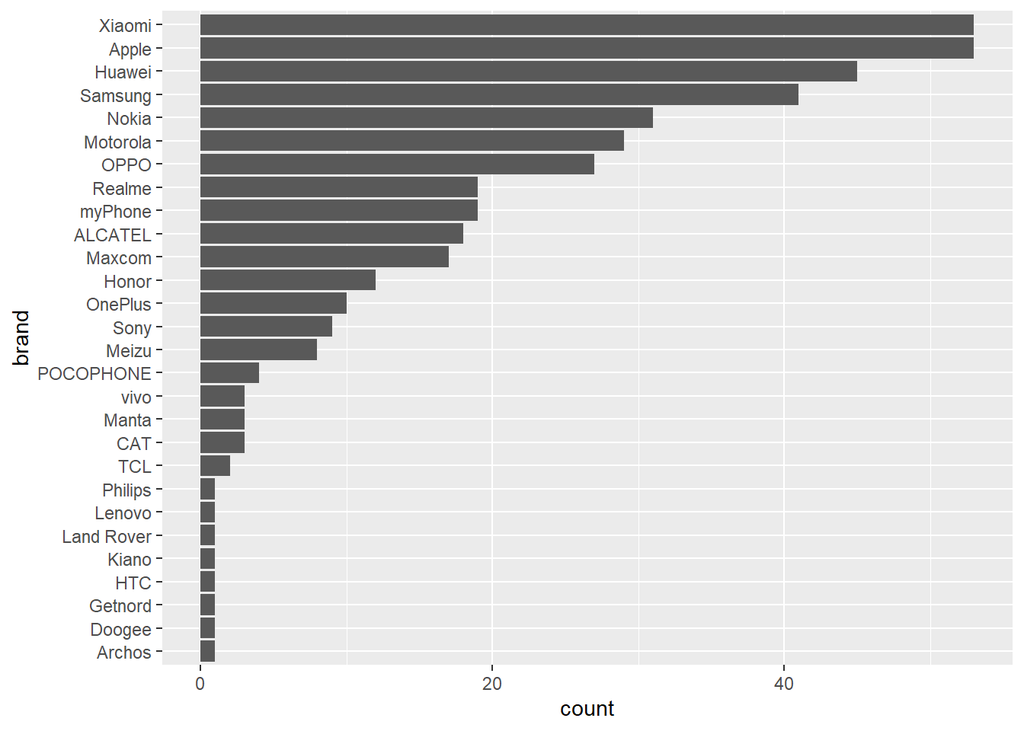

`name` variable:

|  | Unique | Total | Percent |
| --- | --- | --- | --- |
| name | 328 | 414 | 0.7922705 |

### Numerical variables

For various variables shown below, there are a lot of different values for each, there are no clearly visible dominant values. On chart about screen diagonal, we can see pick moved to the right, the majority of ohones does have diaonal greater than 4.

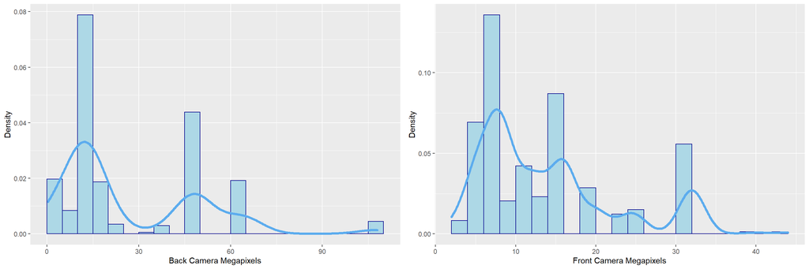

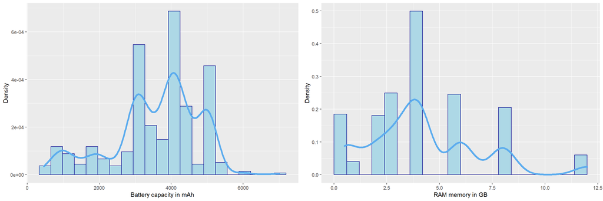

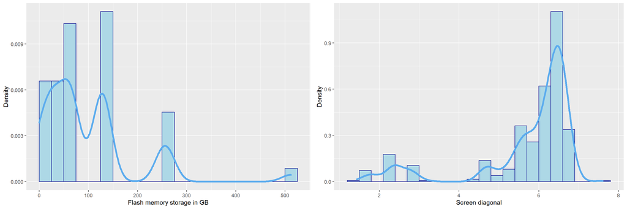

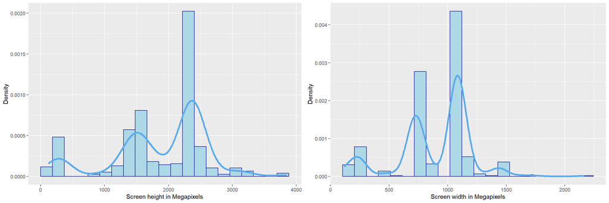

### Target analysis

As we see below, our target seems as if it is from normal distribution, except the fact that it is shifted to the left, the majority of phones cost less than 2500 zł.

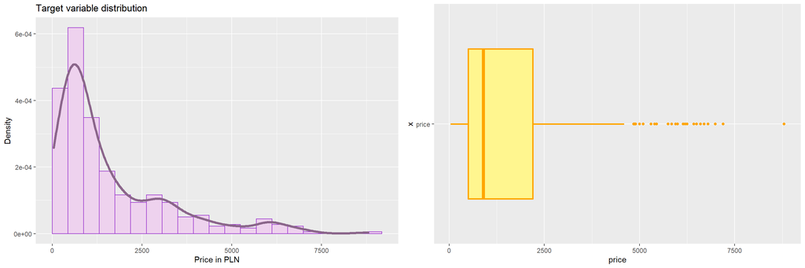

#### Most popular brands vs target

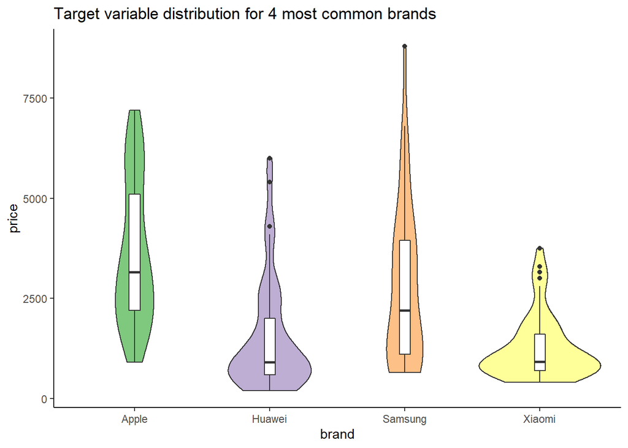

### Correlations

#### Height & width

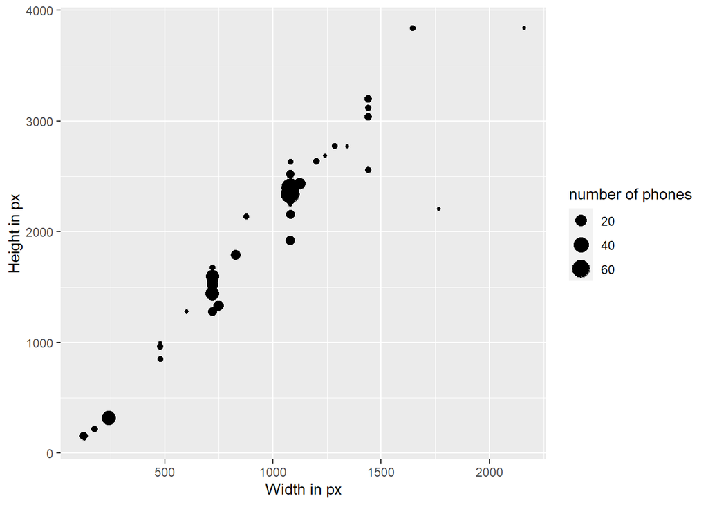

Above we see that there is nearly linear dependence between *height_px* and *width_px*.

#### All numerical variables

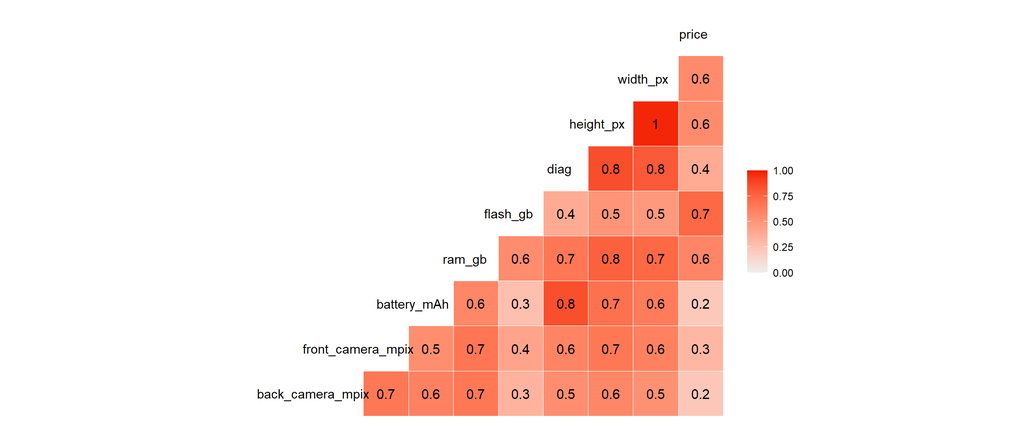

Correlation between *flash_gb* and *price* seems to be highest, and between *ram_gb*, *width_px*, *height_px* and target seems also to be high.

#### Relationships between variables

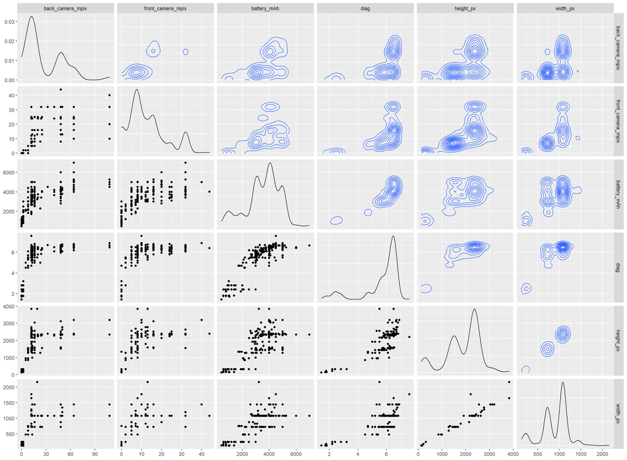

### Summary

Dataset phones has few missing values, which will make modelling easier. Before creating first models, there are some issues to consider.

- Variables describing phone’s size are strongly correlated. Maybe we should resign from two of them.
- There are some brands that are represented by few phones. Maybe we should merge them with label ‘other’.